# GIS For Sustainability and Resilience, Techniques Final Project: The Spread Invasive Species Through the Hawaiian Islands

Clemens Mayer

2024-10-16

[figure not shown]

[figure not shown]

## Introduction: The Hawaiian Islands and Invasive Species

The Hawaiian Islands are a volcanic island chain in the middle of the Pacific Ocean. They consist of 7 inhabited islands, located at the southeastern end of the chain, and a large number of uninhabited islands, named the *Leeward Islands*. This project will focus on the southeastern, inhabited islands only.

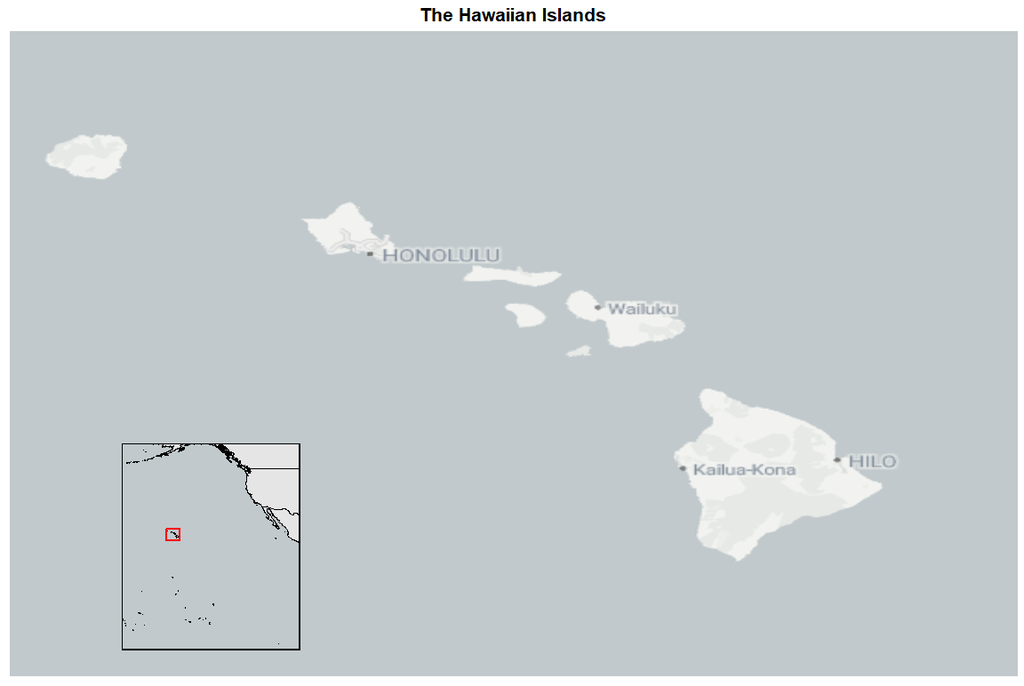

The Hawaiian islands, being a remote island chain in the middle of the Pacific Ocean, has ecosystems that are relatively fragile, and especially vulnerable to invasive species. This is due to its island nature: The endemic species of flora and fauna that have evolved here over the past several millions years have done in relatively fixed ecosystem. This does not mean that there is no biotic interchange on remote islands. Rather, interchange is incredibly slow and only due to long-distance aquatic or aerial travel capacities, being carried by such hosts (such as seed by birds), or, much more recently, through anthropogenic introduction. Thus, endemic Hawaiian species are incredibly adapted to their local ecosystems, but have few defenses against differently-evolved external species. The first major introduction of non-endemic species occurred with the first settling of the Hawaiian islands around 1,000 years ago by Austronesians from the Society Islands. This introduced many so-called *waʻa plants*, such as kalo (taro), tī, ʻolena (turmeric), ʻulu (breadfruit), and many more. As many of these species now grow wild throughout the Hawaiian islands, these are technically also invasive species. However, their adaptations to thrive in island ecosystems, and most likely carefully chosen features by their introducers, mean that these species generally do not dominate and deteriorate ecosystems (though not all, cf. feral pigs).

However, since the start of continued relationships of the Hawaiian Islands with external landmasses, especially North American and (South-East) Asia, there has been a massive increase of invasive species throughout the Islands in the last 150 or so years. Factors include agriculture, cattle farming, ornamentals, and accidental introduction. Invasives include well-known flora and fauna such as mongoose, cockroaches, mosquitoes, elephant grass, and guava, but also some that are seen as iconic for the Hawaiian islands such as Myna birds, Crown Flower, and Plumerias. Due to an all-time high, and ever increasing, degree of contact with Hawaii with other landmasses, invasive species are seemingly almost constantly introduced, and in some cases have devastating effects on local ecosystems. Although there are many smaller and larger efforts to fight invasive species, it is a constant uphill battle.

This project focuses on three such uphill battles of three small but hugely detrimental animals: The coqui frog, the coconut rhinoceros beetle (CRB), and the Little Fire Ant (LFA). I have chosen to focus on these three species because they are very invasive, form a large threat to human and ecosystem health, and are not fully established throughout the Hawaiian Islands. The latter point is especially important here because it means that visibility of these issues, and the coming together of community and state-based agencies can mean that these species can still be stopped from establishing universally throughout the islands. The main focus, however, will be on coqui frogs, as these seem to have the largest amount of observation data available.

## Coqui frog (*Eleutherodactylus coqui*)

The Coqui frog is well-establish on Hawaii Island at this point, especially on the Northeastern side, such as in Puna. However, recently there have been increasing observations of occurrences on other islands, notably Oʻahu. Although (public) observations generally lag behind on actual spread, some observations have been noted in recent years, as shown in the animated map below. Additionally, certain agencies, such as the Hawaii Department of Forestry and Wildlife (DOFAW), who are currently working with community members in fighting Coqui, are currently not publicly sharing their observations, whether they have been collected by community members or their staff (Ryan Chang, DOFAW employee, pers. comm.).

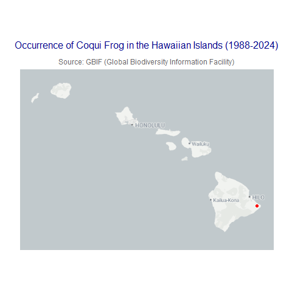

It is interesting to see that the major colonies of coqui are clustered in certain areas, mainly the east. To see what might be causing this, I introduced raster layers for annual mean temperature and annual precipitation. The data used for this stems WordClim, using the Bioclimatic variables 30 seconds (bio 30s) data. In order to visualize possible confounding effects of the spread of Coqui, these maps are focused on Hawaii Island.

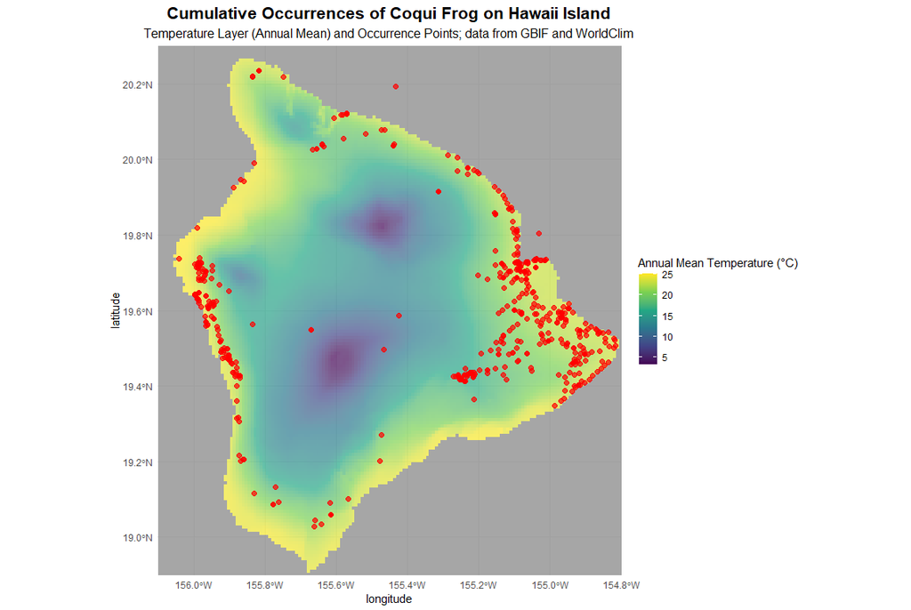

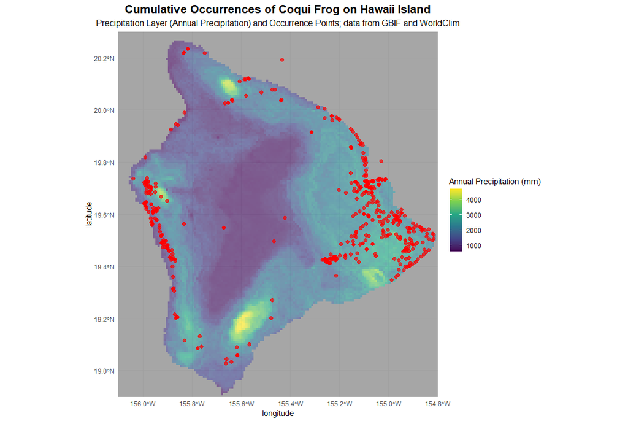

In this map we can see that, with a few outliers, Coqui occur in areas with a high amount of rainfall. When looking at the western side of the island, it shows that Coqui fit right into a strip along the coast where there is a lot of rainfall, but still a comfortable temperature for them due to relatively low elevation.

As shown in the maps above, Coqui frogs are already very well established on Hawaii Island. However, as shown in the animated map at the start of this section, they are only just beginning to establish on other islands. Using the visualizations and the correlated data from temperature and precipitation, we can more easily scout locations of possible occurrences, and thus more easily prevent their spread. Additionally, since we know that Coqui can travel on plants, we must be extra careful in handling and inspecting plants coming from Hawaii Island onto the other islands.

## Coconut Rhinoceros Beetle (*Oryctes rhinoceros*)

The next species we will be looking at is the Coconut Rhinoceros Beetle (CRB). CRB is a highly invasive species that is devastation to palm trees. According to [CRB Response](https://www.crbhawaii.org/), and as reflected in the following map, CRB is not yet established throughout the islands, but is mainly focused on Oʻahu.

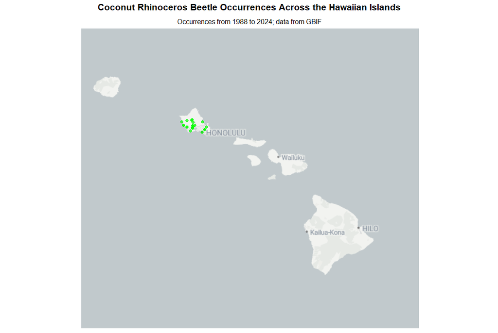

Sadly, the observations in the above map do not correspond exactly to the occurrence of CRB, as it is much more wide-spread on Oʻahu, and there have been (minor) detections on Kauaʻi, Maui, and Hawaiʻi Island. This is another reason why it should be encouraged for governmental and non-governmental entities that track invasive species to share their (raw) data publicly through resources such as [GBIF](https://gbif.org).

However, CRB larvae are known to proliferate in mulch piles and green waste, and will happily tag along for the ride when this green waste is transported. Therefore, we should expect CRB occurrences to be more prevalent close to human settlements. By taking the constrained population data of 2020 (the most recent available) from [Worldpop](https://worldpop.org), and adding this to the layer, we see a relatively neat trend appear:

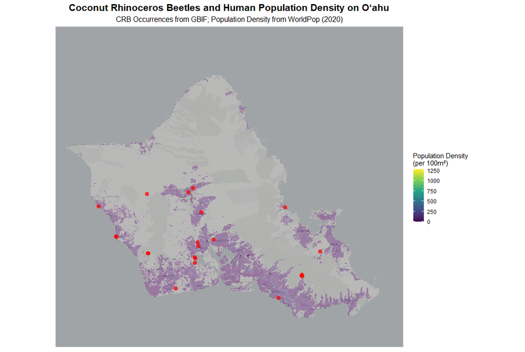

It must, however, be noted that this may also be an instance of biased data, as observations uploaded to publicly available spaces such as iNaturalist are much more likely to be made close to where humans generally are. Nonetheless, the above map shows a neat human-flora interface in the spread and proliferation of invasive species. It is known that the remove of mulch piles, such as through burning, is an effective way to get rid of CRB larvae. However, it has been difficult to convince people to do this. Additionally, since CRB larvae have been found in soil bags purchased from retailers such as Home Depot, it is especially important for those purchasing soil to check it thoroughly whenever opening a bag. More importantly, however, producers of soil should be doing additional quality control to ensure no CRB larvae remain in soil bags.

## Little Fire Ant (*Wasmannia auropunctata*)

The last species discussed in this project is the Little Fire Ant (LFA). LFA is a particularly nasty invasive species, and has some of the most direct impacts on human health of the species discussed here: These small ants have a very painful bite, strong enough to blind pets and incapacitate children. They also nest in trees, meaning that they can easily drop down onto a person or other animal. LFA are a relatively recent invasive species, and especially community members are working very hard to prevent their permanent settlement on these islands, as it would destroy certain parts of the Hawaiian way of life.

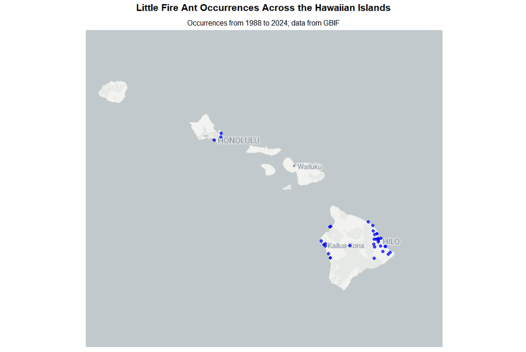

With the few occurrences we do have, and the knowledge of LFA preferences, we can look at the ground cover (from [LCMS2023](https://data.fs.usda.gov/geodata/rastergateway/LCMS/)), again zoomed in to Hawaii Island for ease of visualization, and see if there are any correlations.

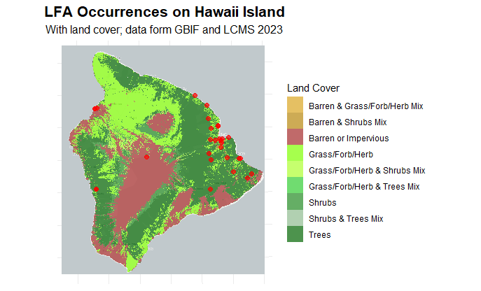

To no surprise, LFA are mainly found in forested or grass-forest-herb mixed areas, and especially common around relatively populated areas. Since invasive species are nowadays mainly introduced by humans, especially through the plant and animal trade, it is no surprise that initial establishment of invasives is close to their place of introduction.

The fighting of all three invasive species discussed here is a very current issue. However, LFA is a very recent, and very pressing issue. All of these invasive species impact us negatively, but LFA has very direct impacts on our wellbeing. The are multiple grassroots campaigns and action groups that are working directly in communities affected by LFA, but the state-wide effort (for example the Hawaii Ant Lab, which is set to be dismantled) has been floundering due to lack of resources and manpower.

## Interactive map of the three invasive species

As a small, interactive map below shows you the three invasive species discussed in this project, as well as some of the additional raster layers used. By switching the raster layers on and off, it can be used to detect further trends not detected by myself so far.

[interactive chart not shown]